# Weather data

Knit on

November 14, 2026

# 1 Setup

```r
library(conflicted)
library(tidyverse)
library(plotly)
library(mice)
library(ggmice)
library(ggrepel)
library(DT)
library(lmodel2)

set.seed(19347)

conflicts_prefer(dplyr::filter)
conflicts_prefer(dplyr::select)

options(DT.options = list(pageLength = 10))

theme_set(theme_minimal())

load("intermediate/SES.RData")

#process FD dataframe
results_sites <- results_sites |>
  rename(year = date, site = plot)

years <- unique(results_all$date)
```

## 1.1 Matrix product backend

Despite setting a seed, imputations with `mice()` from different machines or operating systems might differ slightly, while imputations from the same machine and OS should be fully reproducible. I narrowed this down to different matrix product implementations. To circumvent this problem, the following line sets NETLIB as default matrix backend (default on Windows) if available. Alternatively, use the provided `weather.RData` file in notebooks following this one.

```r
if (.Platform$OS.type == "unix"){
  library(flexiblas)
  if(flexiblas_avail() && "NETLIB" %in% flexiblas_list()){
    flexiblas_switch(flexiblas_load_backend("NETLIB"))
  }
  flexiblas_current_backend()
}
```

```
[1] "NETLIB"
```

Based on the vegetation surveys, my years of interest are 1999, 2000, 2001, 2002, 2005, 2006, 2008, 2011.

# 2 Sample dates

The weather data will be summarized as annual means, starting as monthly averages. To respect causality, since the vegetation sampling was carried out in summer, instead of calculating the means for the solar year, we calculate it from the 12 months before the sampling in each case. This chunk gets the date for each sampling, and makes a sequence of the 12 months before.

```r
#toy example
toy <- tibble(plot = 1:2,
              date = c("15/05/2001", "02/07/1999")) |>
  mutate(date = dmy(date)) |>
  mutate(year_before = date - years(1)) |>
  mutate(month = map(year_before, \(x) x %m+% months(0:11))) |>
  unnest(month) |>
  mutate(year = year(month),
         month = month(month))

head(toy, 13)
```

| plot | date | year_before | month | year |
| --- | --- | --- | --- | --- |
| 1 | 2001-05-15 | 2000-05-15 | 5 | 2000 |
| 1 | 2001-05-15 | 2000-05-15 | 6 | 2000 |
| 1 | 2001-05-15 | 2000-05-15 | 7 | 2000 |
| 1 | 2001-05-15 | 2000-05-15 | 8 | 2000 |
| 1 | 2001-05-15 | 2000-05-15 | 9 | 2000 |
| 1 | 2001-05-15 | 2000-05-15 | 10 | 2000 |
| 1 | 2001-05-15 | 2000-05-15 | 11 | 2000 |
| 1 | 2001-05-15 | 2000-05-15 | 12 | 2000 |
| 1 | 2001-05-15 | 2000-05-15 | 1 | 2001 |
| 1 | 2001-05-15 | 2000-05-15 | 2 | 2001 |
| 1 | 2001-05-15 | 2000-05-15 | 3 | 2001 |
| 1 | 2001-05-15 | 2000-05-15 | 4 | 2001 |
| 2 | 1999-07-02 | 1998-07-02 | 7 | 1998 |

```r
#tibble to refer plot codes to plot names
site_lookup <- tibble(code_plot = c(1, 3, 4, 20),
                      site = c("01-ABR1", "03-CAL1", "04-CAM1", "20-VEN1"))

dates <- read_csv("Data/sample_dates.csv") |>
  filter(code_country == 5) |> # Italy is 5
  filter(code_plot %in% site_lookup$code_plot) |> # only sites of interest
  filter(survey_year %in% years) |> # only years of interest
  filter(code_fence == 1) |> # only surveys inside the plot
  mutate(date_sampling = ymd(date_sampling)) |>
  filter(month(date_sampling) |> between(6, 8)) |>  # take summer survey
  mutate(year_before = date_sampling - years(1)) |>
  mutate(month = map(year_before, \(x) x %m+% months(0:11))) |>
  unnest(month) |>
  mutate(year = year(month),
         month = month(month)) |>
  left_join(site_lookup)

head(dates, 13)
```

| site | code_country | code_plot | survey_year | date_sampling | code_altitude | code_fence | latitude | longitude | year_before | month | year |
| --- | --- | --- | --- | --- | --- | --- | --- | --- | --- | --- | --- |
| 01-ABR1 | 5 | 1 | 1999 | 1999-08-18 | 30 | 1 | 41.84968 | 13.58976 | 1998-08-18 | 8 | 1998 |
| 01-ABR1 | 5 | 1 | 1999 | 1999-08-18 | 30 | 1 | 41.84968 | 13.58976 | 1998-08-18 | 9 | 1998 |
| 01-ABR1 | 5 | 1 | 1999 | 1999-08-18 | 30 | 1 | 41.84968 | 13.58976 | 1998-08-18 | 10 | 1998 |
| 01-ABR1 | 5 | 1 | 1999 | 1999-08-18 | 30 | 1 | 41.84968 | 13.58976 | 1998-08-18 | 11 | 1998 |
| 01-ABR1 | 5 | 1 | 1999 | 1999-08-18 | 30 | 1 | 41.84968 | 13.58976 | 1998-08-18 | 12 | 1998 |
| 01-ABR1 | 5 | 1 | 1999 | 1999-08-18 | 30 | 1 | 41.84968 | 13.58976 | 1998-08-18 | 1 | 1999 |
| 01-ABR1 | 5 | 1 | 1999 | 1999-08-18 | 30 | 1 | 41.84968 | 13.58976 | 1998-08-18 | 2 | 1999 |
| 01-ABR1 | 5 | 1 | 1999 | 1999-08-18 | 30 | 1 | 41.84968 | 13.58976 | 1998-08-18 | 3 | 1999 |
| 01-ABR1 | 5 | 1 | 1999 | 1999-08-18 | 30 | 1 | 41.84968 | 13.58976 | 1998-08-18 | 4 | 1999 |
| 01-ABR1 | 5 | 1 | 1999 | 1999-08-18 | 30 | 1 | 41.84968 | 13.58976 | 1998-08-18 | 5 | 1999 |
| 01-ABR1 | 5 | 1 | 1999 | 1999-08-18 | 30 | 1 | 41.84968 | 13.58976 | 1998-08-18 | 6 | 1999 |
| 01-ABR1 | 5 | 1 | 1999 | 1999-08-18 | 30 | 1 | 41.84968 | 13.58976 | 1998-08-18 | 7 | 1999 |
| 03-CAL1 | 5 | 3 | 1999 | 1999-07-14 | 19 | 1 | 38.42611 | 16.17912 | 1998-07-14 | 7 | 1998 |

```r
#check if exactly 1 each year, site, month
dates |>
  group_by(survey_year, site, month) |>
  count() |>
  ungroup() |>
  tidyr::complete(survey_year, site, month = 1:12) |>
  filter(n != 1)
```

| survey_year | site | month | n |
| --- | --- | --- | --- |

```r
#check if 12 for each survey and site
dates |>
  group_by(site, survey_year) |>
  count() |>
  filter(n != 12)
```

| site | survey_year | n |
| --- | --- | --- |

```r
#these are all the months required for weather data. Some will be missing
dates <- dates |>
  select(site, survey_year, year, month)

#check whether all FD data appears in dates tibble
results_all |>
  distinct(plot, date) |>
  anti_join(dates |>
              rename(plot = site, date = survey_year))
```

| plot | date |
| --- | --- |

```r
#check whether there are dates not corresponding to FD
dates |>
  distinct(site, survey_year) |>
  anti_join(results_all |>
              rename(site = plot, survey_year = date))
```

| site | survey_year |
| --- | --- |

# 3 Monthly data

```r
weat <- read_csv("Data/weather_data.csv") |>
  janitor::clean_names() |>
  rename("type" = type_open_field_vs_in_the_plot) |>
  mutate(type = fct(type, levels = c("ITP", "OFD"))) |>
  select(!starts_with("n_"))
```

## 3.1 Check within-site weather patterns

These are with each year stacked on top of one another.

```r
pat_st <- c("air_t_mean", "soil_t_mean", "solar_radiation_mean",
            "relative_humidity_mean", "precipitation") |>
  set_names() |>
  map(\(v){
    p <- weat |>
      mutate(year = as_factor(year)) |>
      ggplot(aes(x = month, y = .data[[v]], color = year))+
      geom_point(size = 0.8)+
      geom_line(alpha = 0.8)+
      scale_x_continuous(breaks = 1:12)+
      facet_grid(vars(type), vars(site))+
      labs(title = v)
    ggplotly(p)
  })

pat_st |>
  htmltools::tagList()
```

[interactive chart not shown]

These are continuous time series by site.

```r
pat_ts <- c("air_t_mean", "soil_t_mean", "solar_radiation_mean",
            "relative_humidity_mean", "precipitation") |>
  set_names() |>
  map(\(v){
    p <- weat |>
      mutate(date = make_date(year = year, month = month)) |>
      ggplot(aes(x = date, y = .data[[v]], color = type))+
      geom_point(size = 0.8)+
      geom_line(alpha = 0.8)+
      scale_x_date(date_breaks = "1 year", date_labels = "%Y")+
      facet_wrap(vars(site), ncol = 1, axes = "all_x")+
      labs(title = v)
    ggplotly(p)
  })

pat_ts |>
  htmltools::tagList()
```

[interactive chart not shown]

There are some clear inconsistencies in the data. These should be removed before proceeding.

```r
# remove 20-VEN1 soil T ITP in 2010 and 2011
weat <- weat |>
  mutate(soil_t_mean = replace_when(soil_t_mean, site == "20-VEN1" & year %in% 2010:2011 & type == "ITP" ~ NA))

# remove 03-CAL1 soil T OFD in 2013, 2014, 2015
weat <- weat |>
  mutate(soil_t_mean = replace_when(soil_t_mean, site == "03-CAL1" & year %in% 2013:2015 & type == "OFD" ~ NA))

# remove 03-CAL1 solar radiation in July 2011
weat <- weat |>
  mutate(across(c(solar_radiation_mean, solar_radiation_max),
                \(x) replace_when(x, site == "03-CAL1" & year == 2011 & month == 7 ~ NA)))

# remove whole years with 0 precipitation
weat <- weat |>
  mutate(precipitation = replace_when(precipitation, site == "01-ABR1" & year %in% c(2007, 2011, 2012) & type == "ITP" ~ NA,
                                      site == "03-CAL1" & year == 2015 & type == "OFD" ~ NA,
                                      site == "03-CAL1" & year == 2014 & type == "OFD" & month %in% 9:12 ~ NA))
```

## 3.2 Calculating the number of months with weather data for each survey

We have a table which specifies, for each site and sampling year, the required months of weather data. Let’s count how many of those are available.

```r
#only weather data relevant for vegetation surveys here
weat_mo <- weat |>
  semi_join(dates)

datatable(weat_mo)
```

|  | site | type | year | month | air_t_mean | air_t_min | air_t_max | soil_t_mean | soil_t_min | soil_t_max | solar_radiation_mean | solar_radiation_max | relative_humidity_mean | relative_humidity_min | relative_humidity_max | precipitation | wind_speed_mean | wind_speed_max |
| --- | --- | --- | --- | --- | --- | --- | --- | --- | --- | --- | --- | --- | --- | --- | --- | --- | --- | --- |
| 1 | 01-ABR1 | OFD | 2000 | 1 | -2.9 | -5.5 | -0.1 | 0.5 | 0.4 | 0.5 | 75.8 | 480.6 | 76.2 | 53.5 | 93.5 | 5 | 2.7 | 8.1 |
| 2 | 01-ABR1 | OFD | 2000 | 2 | -1.4 | -4.4 | 1.7 | 0.4 | 0.4 | 0.5 | 113.8 | 640.3 | 78 | 49.8 | 97 | 33 | 3 | 8.4 |
| 3 | 01-ABR1 | OFD | 2000 | 3 | 0.7 | -2.5 | 4.1 | 1.6 | 1.2 | 2.2 | 141.6 | 748.3 | 82.1 | 55.8 | 99.1 | 70 | 3.9 | 10.2 |
| 4 | 01-ABR1 | OFD | 2000 | 4 | 3.4 | 0.9 | 6.5 | 4.7 | 4 | 5.5 | 128.4 | 836.8 | 87.4 | 67.9 | 99.8 | 33.8 | 4.4 | 11.6 |
| 5 | 01-ABR1 | OFD | 2000 | 5 | 10.1 | 7.4 | 13.6 | 11.4 | 10.2 | 12.8 | 231 | 1090.4 | 89.7 | 61.6 | 99.9 | 42.6 | 3 | 8.5 |
| 6 | 01-ABR1 | OFD | 2000 | 6 | 13 | 9.4 | 17.2 | 15.3 | 13.9 | 16.8 | 286.2 | 1057.9 | 73.6 | 43.5 | 95.7 | 15.2 | 3.5 | 9.5 |
| 7 | 01-ABR1 | OFD | 2000 | 7 | 16.9 | 12.7 | 21.5 | 17.7 | 16.4 | 19.3 | 316.4 | 1000.6 | 50 | 26.2 | 74.1 | 0 | 4.7 | 11.3 |
| 8 | 01-ABR1 | OFD | 2000 | 8 | 17.3 | 13.6 | 22.1 | 17.9 | 16.6 | 19.3 | 249.5 | 970.1 | 54.8 | 29.4 | 76.5 | 14.6 | 3.1 | 9.9 |
| 9 | 01-ABR1 | OFD | 2000 | 9 | 10.9 | 7.9 | 14.9 | 13.6 | 12.6 | 14.9 | 181.2 | 836.9 | 79 | 49.9 | 97.5 | 122 | 4.2 | 11.5 |
| 10 | 01-ABR1 | OFD | 2000 | 10 | 7.3 | 5.2 | 10.3 | 9 | 8.3 | 9.8 | 100.9 | 724.8 | 90.7 | 70.6 | 97.1 | 152.8 | 4.2 | 10 |

[output cut: 486 more lines]

```r
OFD <- weat_mo |>
  filter(type == "OFD") |>
  right_join(dates)

ITP <- weat_mo |>
  filter(type == "ITP") |>
  right_join(dates)
```

Checking the open field data:

```r
months_OFD <- OFD |>
  group_by(site, survey_year) |>
  summarise(across(where(is.numeric), ~sum(!is.na(.)))) |>
  ungroup() |>
  mutate(across(everything(), ~replace_na(., 0))) |>
  select(-year, -month)

datatable(months_OFD)
```

|  | site | survey_year | air_t_mean | air_t_min | air_t_max | soil_t_mean | soil_t_min | soil_t_max | solar_radiation_mean | solar_radiation_max | relative_humidity_mean | relative_humidity_min | relative_humidity_max | precipitation | wind_speed_mean | wind_speed_max |
| --- | --- | --- | --- | --- | --- | --- | --- | --- | --- | --- | --- | --- | --- | --- | --- | --- |
| 1 | 01-ABR1 | 1999 | 0 | 0 | 0 | 0 | 0 | 0 | 0 | 0 | 0 | 0 | 0 | 0 | 0 | 0 |
| 2 | 01-ABR1 | 2000 | 6 | 6 | 6 | 6 | 6 | 6 | 6 | 6 | 6 | 6 | 6 | 6 | 6 | 6 |
| 3 | 01-ABR1 | 2001 | 12 | 12 | 12 | 12 | 12 | 12 | 12 | 12 | 12 | 12 | 12 | 12 | 12 | 12 |
| 4 | 01-ABR1 | 2002 | 12 | 12 | 12 | 12 | 12 | 12 | 12 | 12 | 12 | 12 | 12 | 12 | 12 | 12 |
| 5 | 01-ABR1 | 2005 | 11 | 11 | 11 | 11 | 11 | 11 | 11 | 11 | 11 | 11 | 11 | 12 | 10 | 10 |
| 6 | 01-ABR1 | 2006 | 12 | 12 | 12 | 12 | 12 | 12 | 12 | 12 | 8 | 8 | 8 | 12 | 12 | 12 |
| 7 | 01-ABR1 | 2008 | 11 | 11 | 11 | 11 | 11 | 11 | 11 | 11 | 11 | 11 | 11 | 11 | 11 | 11 |
| 8 | 01-ABR1 | 2011 | 12 | 12 | 12 | 12 | 12 | 12 | 12 | 12 | 12 | 12 | 12 | 12 | 12 | 12 |
| 9 | 03-CAL1 | 1999 | 0 | 0 | 0 | 0 | 0 | 0 | 0 | 0 | 0 | 0 | 0 | 0 | 0 | 0 |
| 10 | 03-CAL1 | 2000 | 6 | 6 | 6 | 6 | 6 | 6 | 6 | 6 | 6 | 6 | 6 | 6 | 6 | 6 |

[output cut: 22 more lines]

Checking the data in the plot:

```r
months_ITP <- ITP |>
  group_by(site, survey_year) |>
  summarise(across(where(is.numeric), ~sum(!is.na(.)))) |>
  ungroup() |>
  mutate(across(everything(), ~replace_na(., 0))) |>
  select(-year, -month)

datatable(months_ITP)
```

|  | site | survey_year | air_t_mean | air_t_min | air_t_max | soil_t_mean | soil_t_min | soil_t_max | solar_radiation_mean | solar_radiation_max | relative_humidity_mean | relative_humidity_min | relative_humidity_max | precipitation | wind_speed_mean | wind_speed_max |
| --- | --- | --- | --- | --- | --- | --- | --- | --- | --- | --- | --- | --- | --- | --- | --- | --- |
| 1 | 01-ABR1 | 1999 | 0 | 0 | 0 | 0 | 0 | 0 | 0 | 0 | 0 | 0 | 0 | 0 | 0 | 0 |
| 2 | 01-ABR1 | 2000 | 6 | 6 | 6 | 6 | 0 | 0 | 0 | 0 | 3 | 3 | 3 | 6 | 0 | 0 |
| 3 | 01-ABR1 | 2001 | 12 | 12 | 12 | 12 | 6 | 6 | 0 | 0 | 11 | 11 | 11 | 11 | 0 | 0 |
| 4 | 01-ABR1 | 2002 | 10 | 10 | 10 | 9 | 9 | 9 | 0 | 0 | 10 | 10 | 10 | 9 | 0 | 0 |
| 5 | 01-ABR1 | 2005 | 12 | 12 | 12 | 12 | 12 | 12 | 0 | 0 | 12 | 12 | 12 | 7 | 0 | 0 |
| 6 | 01-ABR1 | 2006 | 10 | 10 | 10 | 10 | 10 | 10 | 0 | 0 | 10 | 10 | 10 | 6 | 0 | 0 |
| 7 | 01-ABR1 | 2008 | 12 | 12 | 12 | 12 | 12 | 12 | 0 | 0 | 12 | 12 | 12 | 7 | 0 | 0 |
| 8 | 01-ABR1 | 2011 | 11 | 11 | 11 | 11 | 11 | 11 | 0 | 0 | 11 | 11 | 11 | 6 | 0 | 0 |
| 9 | 03-CAL1 | 1999 | 0 | 0 | 0 | 0 | 0 | 0 | 0 | 0 | 0 | 0 | 0 | 0 | 0 | 0 |
| 10 | 03-CAL1 | 2000 | 3 | 3 | 3 | 3 | 3 | 3 | 0 | 0 | 3 | 3 | 3 | 3 | 0 | 0 |

[output cut: 22 more lines]

And the difference between the two (ITP-OFD):

```r
type_diff <- months_ITP[1:2] |>
  bind_cols(months_ITP[3:ncol(months_ITP)]- months_OFD[3:ncol(months_OFD)])
datatable(type_diff) |>
  formatStyle(names(type_diff), backgroundColor = styleInterval(-1, c("pink", "white")))
```

|  | site | survey_year | air_t_mean | air_t_min | air_t_max | soil_t_mean | soil_t_min | soil_t_max | solar_radiation_mean | solar_radiation_max | relative_humidity_mean | relative_humidity_min | relative_humidity_max | precipitation | wind_speed_mean | wind_speed_max |
| --- | --- | --- | --- | --- | --- | --- | --- | --- | --- | --- | --- | --- | --- | --- | --- | --- |
| 1 | 01-ABR1 | 1999 | 0 | 0 | 0 | 0 | 0 | 0 | 0 | 0 | 0 | 0 | 0 | 0 | 0 | 0 |
| 2 | 01-ABR1 | 2000 | 0 | 0 | 0 | 0 | -6 | -6 | -6 | -6 | -3 | -3 | -3 | 0 | -6 | -6 |
| 3 | 01-ABR1 | 2001 | 0 | 0 | 0 | 0 | -6 | -6 | -12 | -12 | -1 | -1 | -1 | -1 | -12 | -12 |
| 4 | 01-ABR1 | 2002 | -2 | -2 | -2 | -3 | -3 | -3 | -12 | -12 | -2 | -2 | -2 | -3 | -12 | -12 |
| 5 | 01-ABR1 | 2005 | 1 | 1 | 1 | 1 | 1 | 1 | -11 | -11 | 1 | 1 | 1 | -5 | -10 | -10 |
| 6 | 01-ABR1 | 2006 | -2 | -2 | -2 | -2 | -2 | -2 | -12 | -12 | 2 | 2 | 2 | -6 | -12 | -12 |
| 7 | 01-ABR1 | 2008 | 1 | 1 | 1 | 1 | 1 | 1 | -11 | -11 | 1 | 1 | 1 | -4 | -11 | -11 |
| 8 | 01-ABR1 | 2011 | -1 | -1 | -1 | -1 | -1 | -1 | -12 | -12 | -1 | -1 | -1 | -6 | -12 | -12 |
| 9 | 03-CAL1 | 1999 | 0 | 0 | 0 | 0 | 0 | 0 | 0 | 0 | 0 | 0 | 0 | 0 | 0 | 0 |
| 10 | 03-CAL1 | 2000 | -3 | -3 | -3 | -3 | -3 | -3 | -6 | -6 | -3 | -3 | -3 | -3 | -6 | -6 |

[output cut: 22 more lines]

## 3.3 Plotting the weather data completeness

These are the number of months with weather data for each survey year and site.

```r
months_weat <- bind_rows(list(ITP = months_ITP, OFD = months_OFD), .id = "type") |>
  mutate(survey_year = as_factor(survey_year))
```

```r
plotweat <- function(x, var){
    x |>
  select(1:3, {{var}}) |>
  ggplot(aes(x = survey_year, y = {{var}}, fill = type))+
  geom_col(position = "dodge")+
  scale_x_discrete(drop = FALSE) +
  scale_y_continuous(breaks = seq(0, 12, 2))+
  facet_wrap(~site)+
  theme(axis.text.x = element_text(angle = 90))
}
```

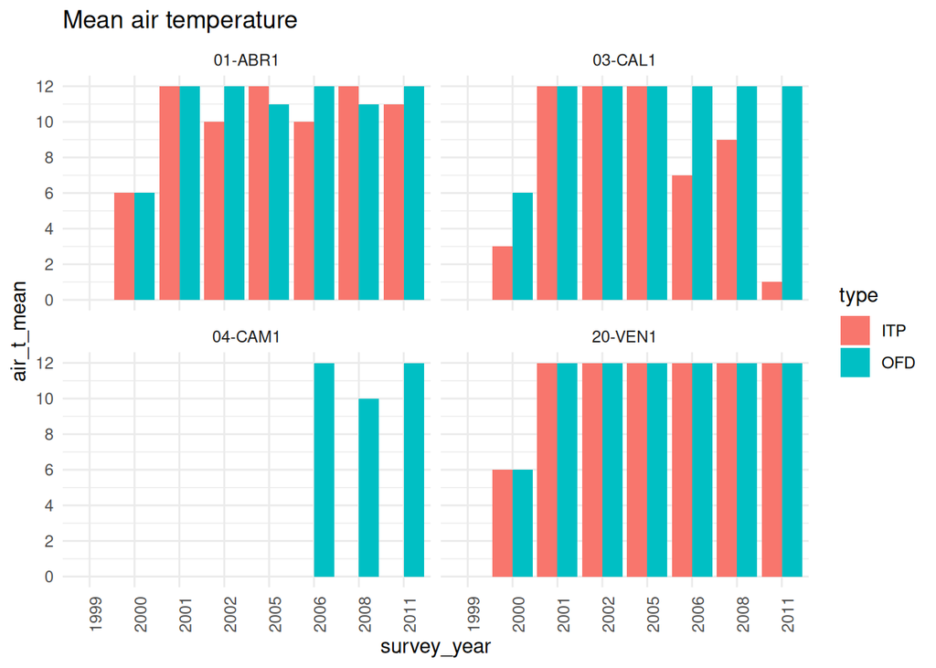

```r
plotweat(months_weat, air_t_mean)+
  ggtitle("Mean air temperature")
```

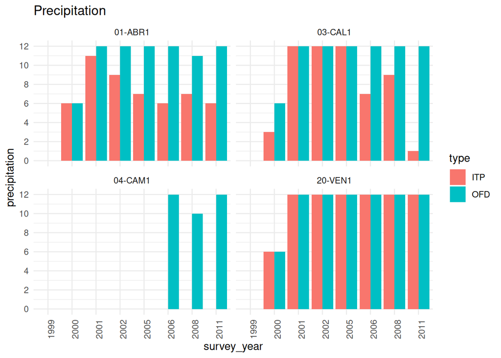

```r
plotweat(months_weat, precipitation)+
  ggtitle("Precipitation")
```

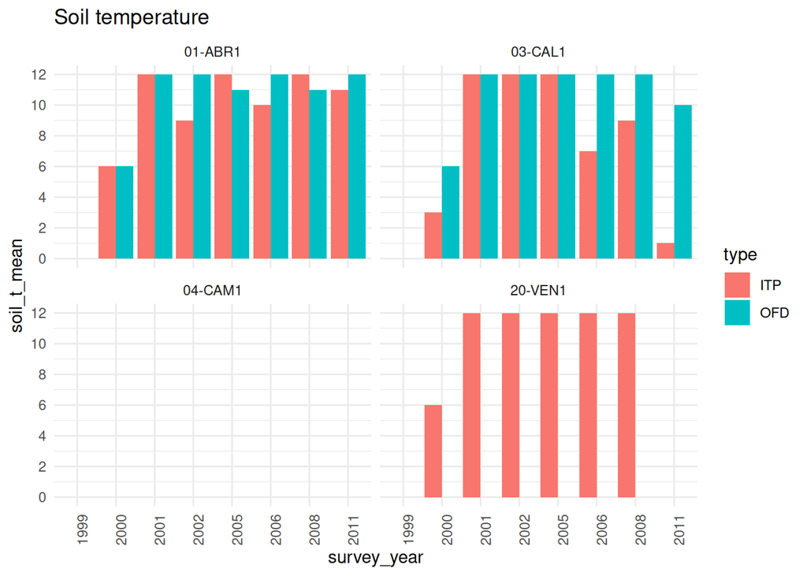

```r
plotweat(months_weat, soil_t_mean)+
  ggtitle("Soil temperature")
```

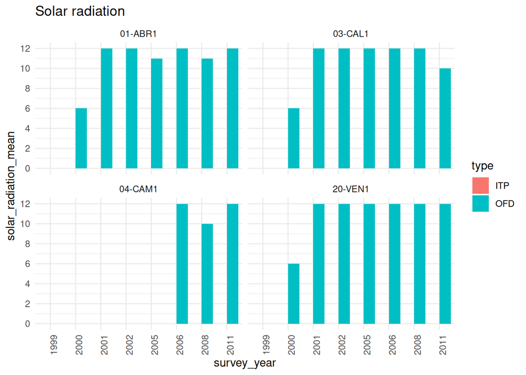

```r
plotweat(months_weat, solar_radiation_mean)+
  ggtitle("Solar radiation")
```

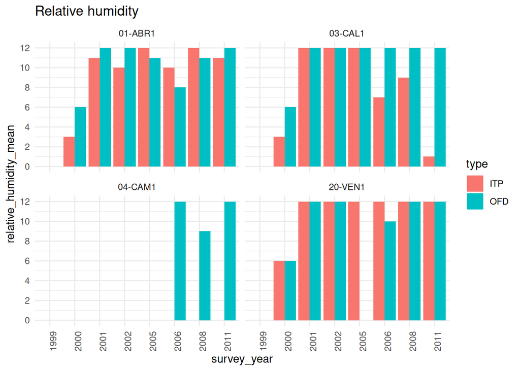

```r
plotweat(months_weat, relative_humidity_mean)+
  ggtitle("Relative humidity")
```

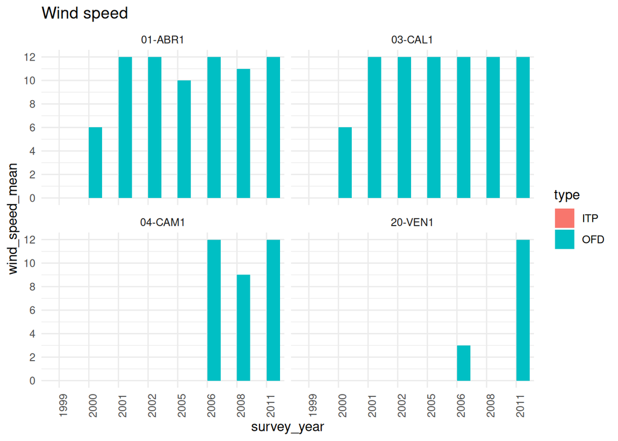

```r
plotweat(months_weat, wind_speed_mean)+
  ggtitle("Wind speed")
```